# Ejemplo de R Markdown: *El voto autonómico en la comarca de la Safor (VALENCIA)*

# 4. GRÁFICOS Y TABLAS

Vemos a continuación los gráficos y tablas de daraso a nivel de agregación de candidatura. Creamos por cada partido (columna del *df_resultats*):

- Un data_frame
- Un gráfico
- Una tabla

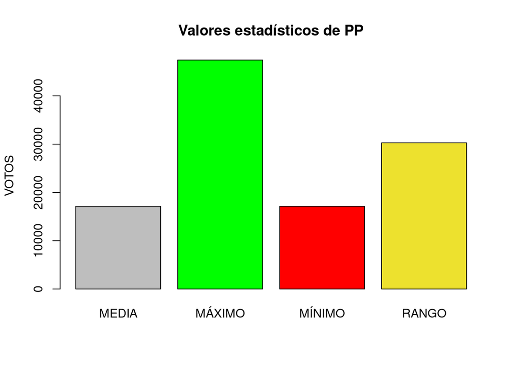

ESTADÍSTICA SAFOR PP

| ESTADÍSTICA | VALORS |
| --- | --- |
| MEDIA | 17142 |
| MÁXIMO | 47413 |
| MÍNIMO | 17142 |
| RANGO | 30271 |

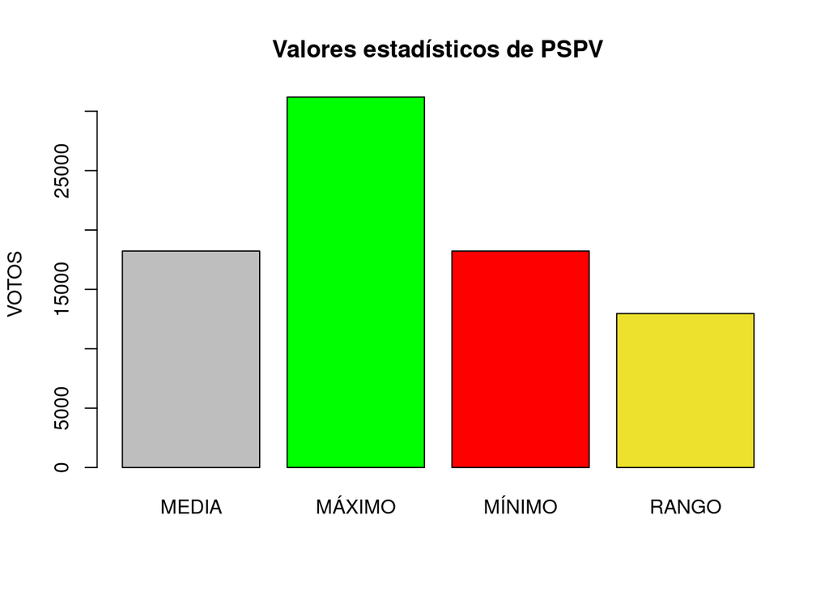

ESTADÍSTICA SAFOR PSPV

| ESTADÍSTICA | VALORS |
| --- | --- |
| MEDIA | 18226 |
| MÁXIMO | 31192 |
| MÍNIMO | 18226 |
| RANGO | 12966 |

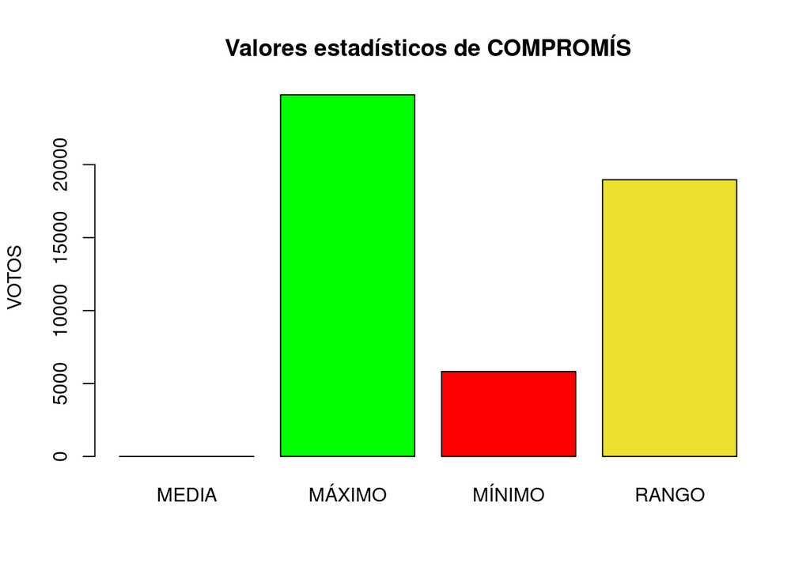

ESTADÍSTICA SAFOR COMPROMÍS

| ESTADÍSTICA | VALORS |
| --- | --- |
| MEDIA | 0 |
| MÁXIMO | 24789 |
| MÍNIMO | 5823 |
| RANGO | 18966 |

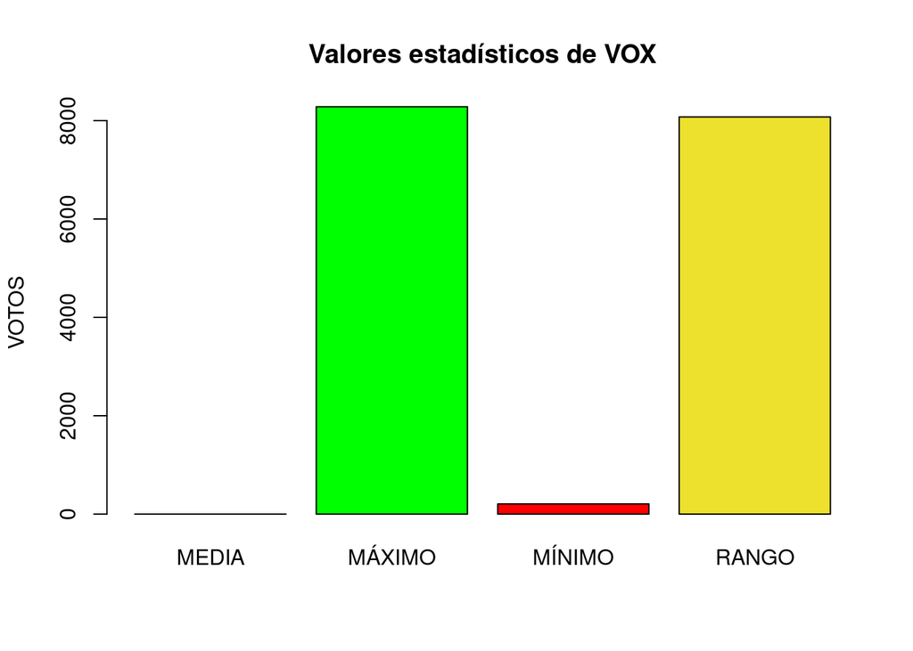

ESTADÍSTICA SAFOR VOX

| ESTADÍSTICA | VALORS |
| --- | --- |
| MEDIA | 0 |
| MÁXIMO | 8282 |
| MÍNIMO | 207 |
| RANGO | 8075 |

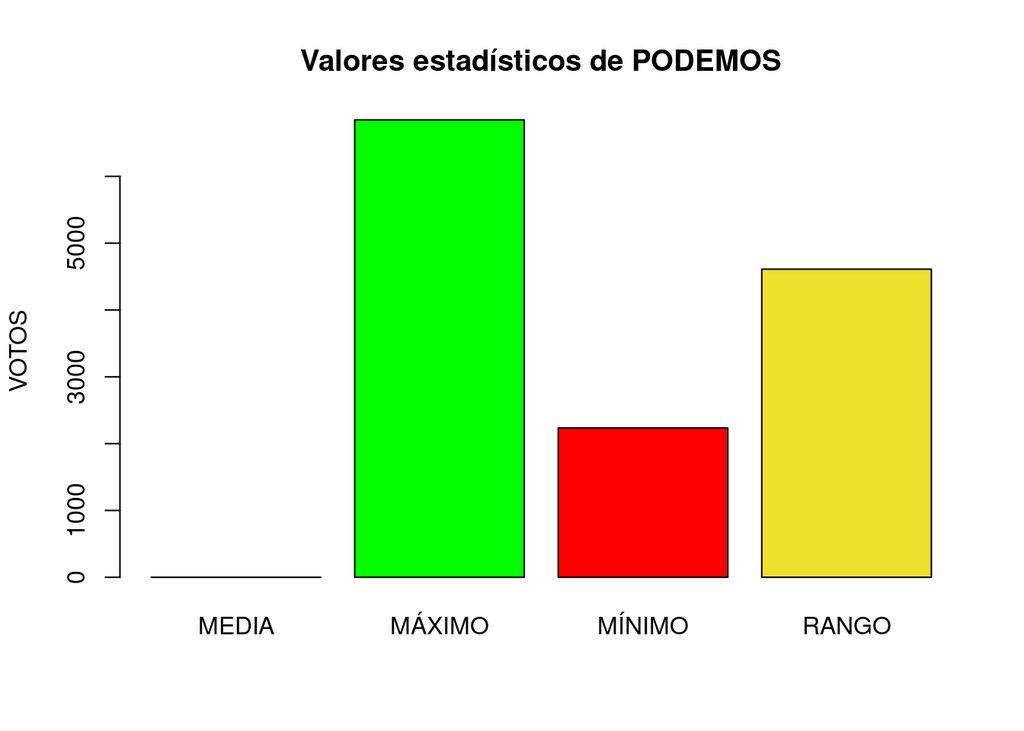

ESTADÍSTICA SAFOR PODEMOS

| ESTADÍSTICA | VALORS |
| --- | --- |
| MEDIA | 0 |
| MÁXIMO | 6845 |
| MÍNIMO | 2234 |
| RANGO | 4611 |

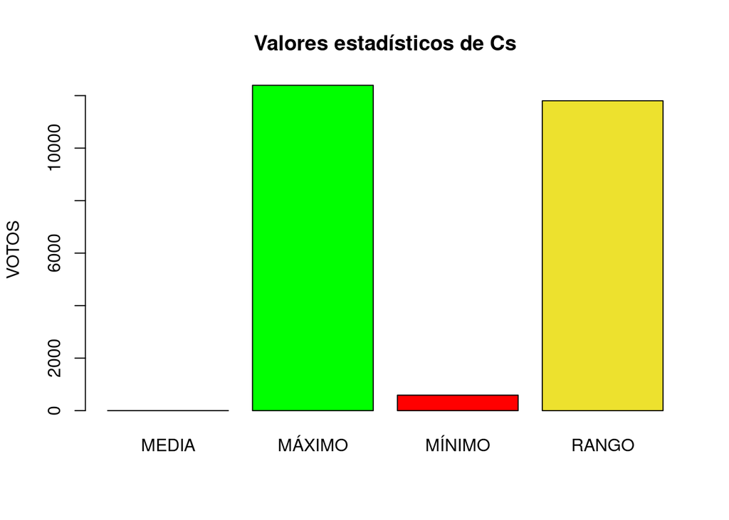

ESTADÍSTICA SAFOR Cs

| ESTADÍSTICA | VALORS |
| --- | --- |
| MEDIA | 0 |
| MÁXIMO | 12394 |
| MÍNIMO | 591 |
| RANGO | 11803 |

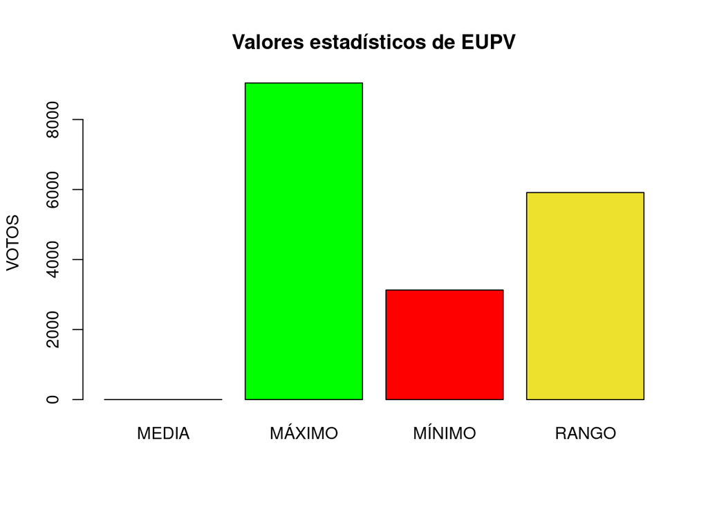

ESTADÍSTICA SAFOR EUPV

| ESTADÍSTICA | VALORS |
| --- | --- |
| MEDIA | 0 |
| MÁXIMO | 9042 |
| MÍNIMO | 3129 |
| RANGO | 5913 |

```r
# Recorremos las columnas del data frame correspondientes a candidaturas ( >2)
# Creamos un data frame en cada iteración
for ( i in 2:length(df_resultats)){
     df_estPartit<- data.frame(
         ESTADÍSTICA=df_resultats$ESTADÍSTICA,
         VALORS=df_resultats[,i],
         PARTIT=colnames(df_resultats[i])
     )

# EN UN GRAFICO
barplot(df_estPartit$VALORS,
        main=paste("Valores estadísticos de",df_estPartit$PARTIT[1]),
        names.arg=df_estPartit$ESTADÍSTICA,
        col=c("gray","green","red","#ede12e"),
        ylab="VOTOS")


# EN UNA TABLA
#Quitamos la columna que repite el nombre ( estético), lo guardamos antes
candidatura<-df_estPartit$PARTIT[1]
df_estPartit <- df_estPartit[, !(names(df_estPartit) %in% "PARTIT")]
knitr::kable(df_estPartit, caption = paste( "ESTADÍSTICA SAFOR",
                        candidatura )) %>% print()

}
```

# 5. GUARDAR DATA FRAME EN FICHEROS DE DIFERENTES FORMATOS

## 5.1 Guardar datos en formato .xlsx (MS Excel)

Se instala el paquete solo si hace falta

```r
if (!require("xlsx")) {install.packages("xlsx")}
```

Se creará un fichero de tipo MS Excel: *resultats.xlsx*

```r
# Si existe lo borramos
if (file.exists("resultats.xlsx")){file.remove("resultats.xlsx")}
```

```
## [1] TRUE
```

```r
# Ahora, lo creamos de nuevo
write.xlsx(df_resultats, file = "resultats.xlsx", sheetName = "resultats", append = FALSE)
```

## 5.2 Añadiendo una hoja en un ficher xlsx existente

Aquí añadiremos una página más a un fichero MS Excel existente (append=TRUE). Si *ficheroAnterior.xlsx* no existe dará error.

```r
# El objeto Workbook de R sirve para carcar un xlsx MS Office 2007 o posterior
# Lo cargamos en la varibel de este tipo wb con la función pertinente
# No comporbamos la existencia del fichero pues se ha creado en el anterior chunk
wb<-loadWorkbook("resultats.xlsx")
# Comprobamos que NO exista la página
if ("resultats" %in% names(wb)) {
  # Si la hoja existe, se remobra (no se puede borrar, tiene que existir al menos 1)
   renameWorksheet(wb, "resultats", "resultatsOLD")

}

# write.xlsx(df_resultats, file="resultats.xlsx", sheetName="resultats1", append=TRUE)
addWorksheet(wb, "resultats")
writeData(wb, sheet = "resultats", x = df_resultats)
saveWorkbook(wb, file="resultats.xlsx",overwrite = TRUE) #guardamos en disco (fichero)
```

## 5.3 Guardar datos en formato .dta / Stata.

```r
if (!require("foreign")) {install.packages("foreign")}
write.dta(df_resultats, "resultats.dta")
```

## 5.4 Guardar datos en formato .csv

```r
if (!require("tidyverse")) {install.packages("tidyverse")}
write_csv(df_resultats, "resultats.csv")
```

## 5.5 Guardar datos en formato .sav / SPSS

```r
if (!require("haven")) {install.packages("haven")}
write_sav(df_resultats, "resultats.sav")
```

## 5.6 Guardar y abrir datos en formato RStudio.

Quizás estemos más habituados a compartir los datos en formatos “comma separated values” u hojas de cálculo. Ahora conoceremos otro tipo de fichero que se manejan muy fácilmente. No requieren librería, pues R ya incorpora funciones para su manejo.

> RData - permite guardar más de una base de datos en un mismo archivo.

```r
save(df_resultats, file="resultats.RData")
```

## 5.7 Lectura de datos RData

El parámetro *verbose=TRUE* es opcional. Sirve para que en la carga (lectura) nos muestre los datos (dataframe en este caso) existentes en el fichero de tipo *.Rdata*. en nuestro ejemplo vemos que contiene el dataframe: *df_resultats*

```r
load("resultats.RData",verbose=TRUE)
```

```
## Loading objects:
##   df_resultats
```

## 5.8 RDS - guarda un solo archivo de datos

```r
saveRDS(df_resultats, "resultats.rds")
```

## 5.9 Lectura de datos RDS

```r
df_resultats2 <- readRDS("resultats.rds")
```